# Image Metric Comparison Report

This report presents the quantitative evaluation of the Image Comparison Metrics Suite across a continuously and evenly sampled generative space (240 combinations: 6 intensity changes × 4 shape changes × 10 magnitude levels).

## 1. Generative Space Evaluation Summary

The table below summarizes the comparison metric scores computed against the image pair space generated by `CrossProductGenerator`. All metric scores are standardized such that a lower score indicates better similarity.

| magnitude_level | intensity_change | shape_change | displacement_magnitude | intensity_magnitude | total_distance | mse | psnr | ncc | ssim | gradient_correlation | ngf_e1 | vgg_4_lncc | dino_2_lncc | resnet_2_lncc | swin_2_lncc |
| --- | --- | --- | --- | --- | --- | --- | --- | --- | --- | --- | --- | --- | --- | --- | --- |
| 6.0 | noise | translation | 685.513306 | 32.839737 | 718.353043 | 0.078515 | -11.801602 | 0.490039 | 0.925275 | 0.900734 | 0.999991 | -0.311432 | -0.354296 | -0.450206 | 0.0 |
| 6.0 | noise | rotation | 1165.068726 | 32.839737 | 1197.908463 | 0.011762 | -20.103104 | 0.064519 | 0.677083 | 0.327229 | 0.999905 | -0.591085 | -0.570771 | -0.837772 | 0.0 |
| 6.0 | noise | affine | 543.188232 | 32.839737 | 576.027969 | 0.065102 | -12.806863 | 0.373367 | 0.836654 | 0.793797 | 0.999977 | -0.384571 | -0.430089 | -0.531950 | 0.0 |
| 6.0 | noise | deformation | 363.007446 | 32.839737 | 395.847183 | 0.025625 | -16.858966 | 0.164573 | 0.817628 | 0.603832 | 0.999922 | -0.415726 | -0.455738 | -0.733444 | 0.0 |
| 6.0 | bias | translation | 685.513306 | 15.682262 | 701.195568 | 0.082603 | -11.075913 | 0.503994 | 0.575254 | 0.901570 | 0.999994 | -0.413882 | -0.458638 | -0.419874 | 0.0 |
| 6.0 | bias | rotation | 1165.068726 | 15.682262 | 1180.750988 | 0.010067 | -20.142859 | 0.061144 | 0.175471 | 0.235863 | 0.999913 | -0.802050 | -0.771470 | -0.843649 | 0.0 |
| 6.0 | bias | affine | 543.188232 | 15.682262 | 558.870495 | 0.062024 | -12.074430 | 0.375555 | 0.451383 | 0.777395 | 0.999982 | -0.515106 | -0.583232 | -0.531594 | 0.0 |
| 6.0 | bias | deformation | 363.007446 | 15.682262 | 378.689708 | 0.025053 | -16.011368 | 0.152748 | 0.383515 | 0.555757 | 0.999929 | -0.538870 | -0.610422 | -0.736150 | 0.0 |
| 6.0 | inhomogeneity | translation | 685.513306 | 37.109401 | 722.622707 | 0.084763 | -10.717938 | 0.514866 | 0.575948 | 0.898754 | 0.999993 | -0.419938 | -0.451635 | -0.416190 | 0.0 |
| 6.0 | inhomogeneity | rotation | 1165.068726 | 37.109401 | 1202.178127 | 0.013728 | -18.624013 | 0.083159 | 0.198290 | 0.245256 | 0.999910 | -0.789631 | -0.753485 | -0.836239 | 0.0 |
| 6.0 | inhomogeneity | affine | 543.188232 | 37.109401 | 580.297634 | 0.062114 | -12.068076 | 0.390376 | 0.474485 | 0.786112 | 0.999979 | -0.508755 | -0.572847 | -0.529609 | 0.0 |
| 6.0 | inhomogeneity | deformation | 363.007446 | 37.109401 | 400.116848 | 0.027819 | -15.556512 | 0.168696 | 0.393807 | 0.572738 | 0.999928 | -0.534308 | -0.593316 | -0.729835 | 0.0 |
| 6.0 | modality | translation | 685.513306 | 570.763893 | 1256.277199 | 0.697978 | -1.561580 | 1.441683 | 1.016394 | 1.032658 | 0.999987 | -0.167255 | -0.242475 | -0.094163 | 0.0 |
| 6.0 | modality | rotation | 1165.068726 | 570.763893 | 1735.832619 | 0.798929 | -0.974917 | 1.895312 | 1.122910 | 1.691929 | 0.999791 | -0.145230 | -0.377278 | -0.009055 | 0.0 |
| 6.0 | modality | affine | 543.188232 | 570.763893 | 1113.952126 | 0.719352 | -1.430588 | 1.634480 | 1.063618 | 1.226587 | 0.999947 | -0.134588 | -0.280158 | -0.046734 | 0.0 |
| 6.0 | modality | deformation | 363.007446 | 570.763893 | 933.771339 | 0.782307 | -1.066229 | 1.751570 | 1.067597 | 1.229905 | 0.999918 | -0.180524 | -0.283320 | -0.039693 | 0.0 |
| 6.0 | step | translation | 685.513306 | 27.903423 | 713.416729 | 0.089775 | -10.468427 | 0.497097 | 0.574700 | 0.920284 | 0.999990 | -0.388705 | -0.426544 | -0.417590 | 0.0 |
| 6.0 | step | rotation | 1165.068726 | 27.903423 | 1192.972149 | 0.010836 | -19.651275 | 0.057624 | 0.194367 | 0.313688 | 0.999872 | -0.734984 | -0.668409 | -0.831706 | 0.0 |
| 6.0 | step | affine | 543.188232 | 27.903423 | 571.091656 | 0.071548 | -11.454013 | 0.364690 | 0.459698 | 0.786267 | 0.999967 | -0.484062 | -0.555920 | -0.523873 | 0.0 |
| 6.0 | step | deformation | 363.007446 | 27.903423 | 390.910870 | 0.028391 | -15.468251 | 0.166628 | 0.393689 | 0.606593 | 0.999895 | -0.511479 | -0.585025 | -0.719402 | 0.0 |
| 6.0 | missing | translation | 685.513306 | 39.119051 | 724.632356 | 0.082226 | -10.849916 | 0.491569 | 0.570559 | 0.895432 | 0.999992 | -0.422834 | -0.467647 | -0.425254 | 0.0 |
| 6.0 | missing | rotation | 1165.068726 | 39.119051 | 1204.187776 | 0.012908 | -18.891423 | 0.077557 | 0.189494 | 0.311900 | 0.999902 | -0.766252 | -0.731481 | -0.815404 | 0.0 |
| 6.0 | missing | affine | 543.188232 | 39.119051 | 582.307283 | 0.068460 | -11.645622 | 0.392426 | 0.457231 | 0.778590 | 0.999974 | -0.515503 | -0.568449 | -0.512474 | 0.0 |
| 6.0 | missing | deformation | 363.007446 | 39.119051 | 402.126497 | 0.029112 | -15.359298 | 0.178665 | 0.393251 | 0.606392 | 0.999918 | -0.528044 | -0.581522 | -0.709311 | 0.0 |

## 2. Generative Space Examples

Below are specific examples of the simulated fixed and moving images across various magnitudes of shape and intensity differences. These visualizations display the simulated original `moving` image alongside its ground truth spatial properties.

### Gallery: All Six Simulated Moving Images

A quick overview of the 6 simulated moving images before detailed inspection.

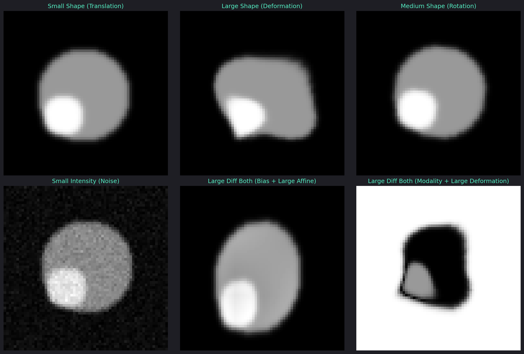

### Small Shape (Translation)

#### Target/Fixed vs Original Moving (Side-by-Side)

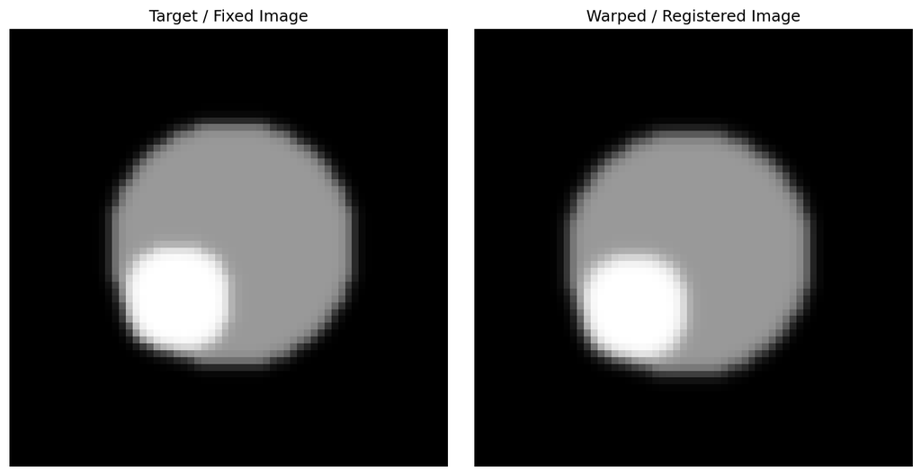

#### Edge Overlap

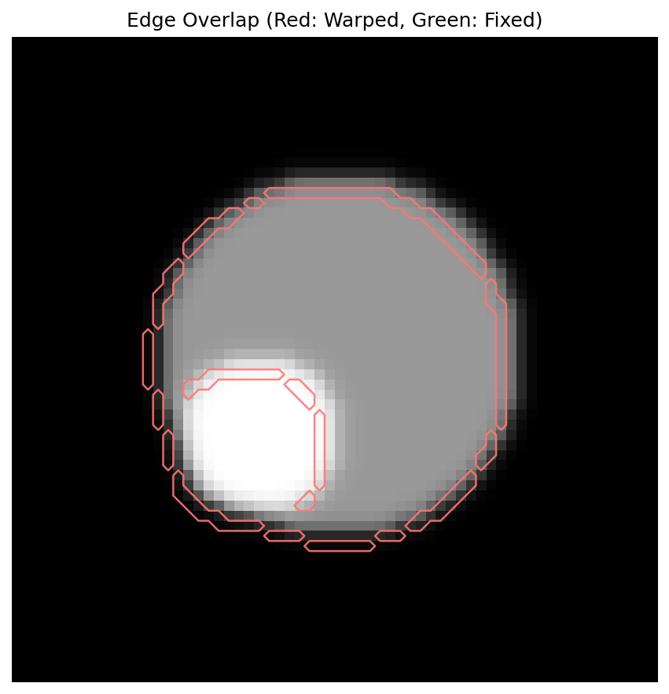

#### Deformation Grid

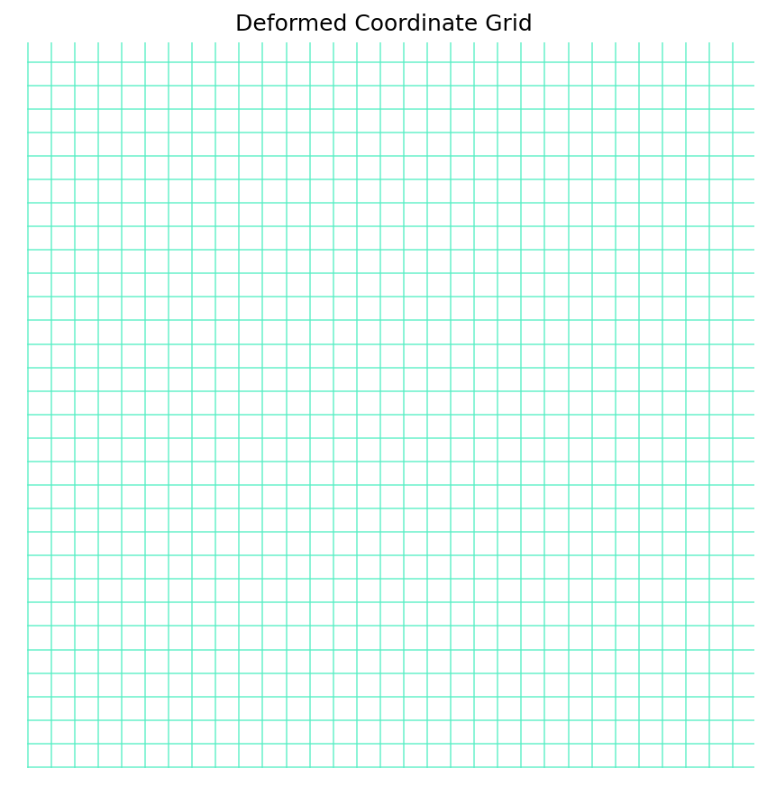

### Large Shape (Deformation)

#### Target/Fixed vs Original Moving (Side-by-Side)

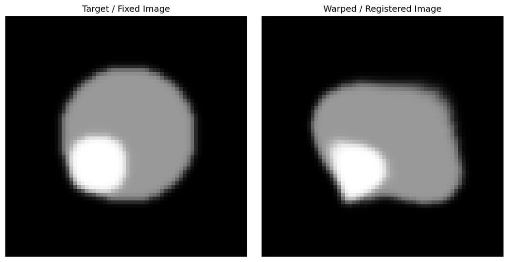

#### Edge Overlap

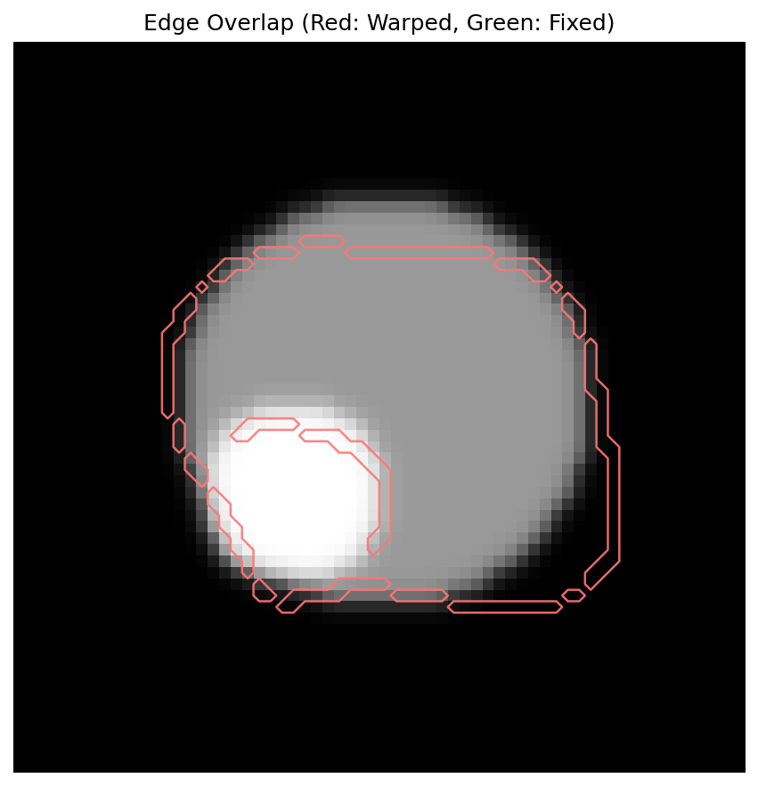

#### Deformation Grid

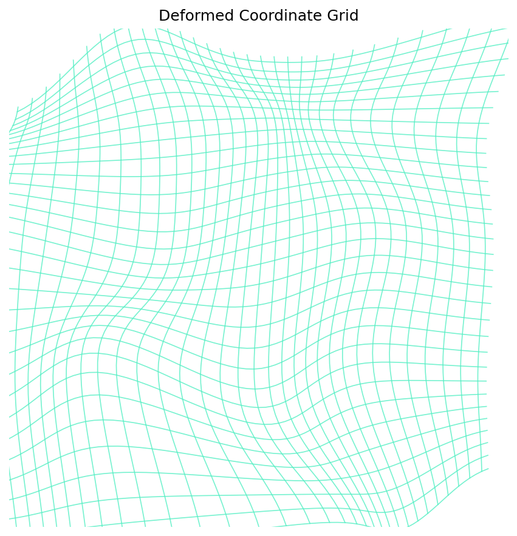

### Medium Shape (Rotation)

#### Target/Fixed vs Original Moving (Side-by-Side)

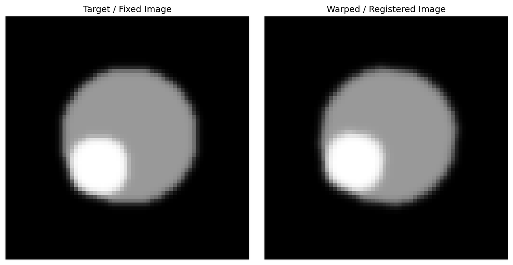

#### Edge Overlap

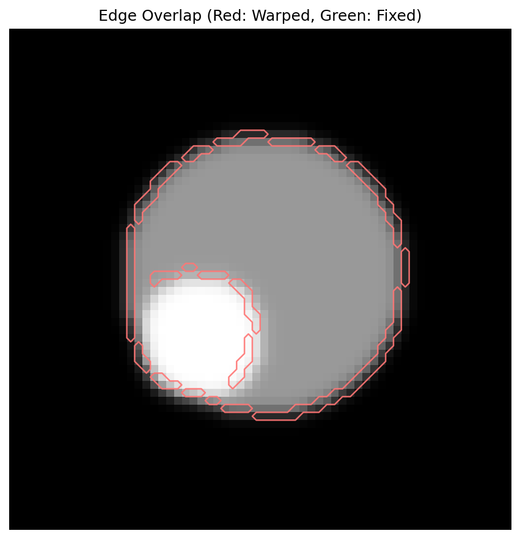

#### Deformation Grid

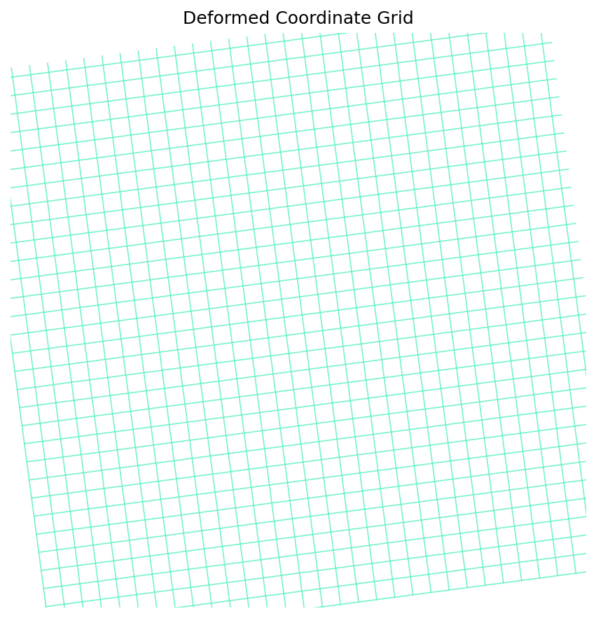

### Small Intensity (Noise)

#### Target/Fixed vs Original Moving (Side-by-Side)

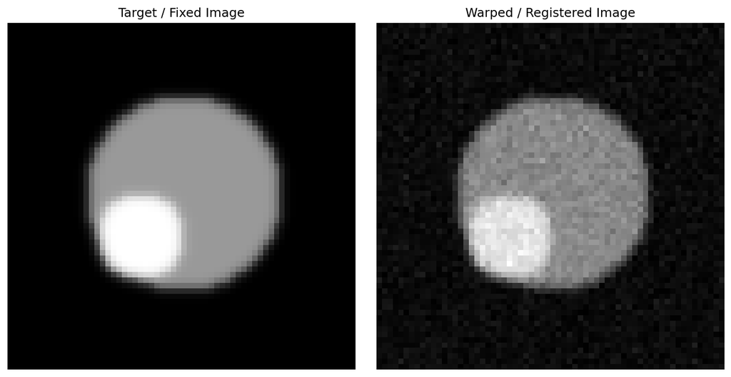

#### Edge Overlap

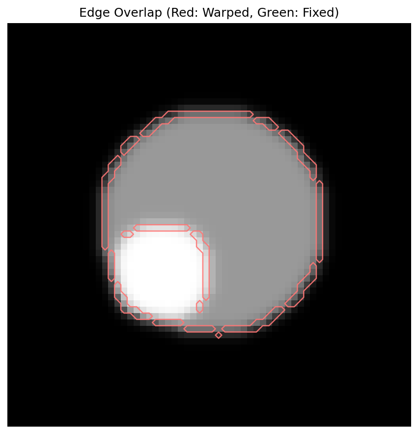

#### Deformation Grid

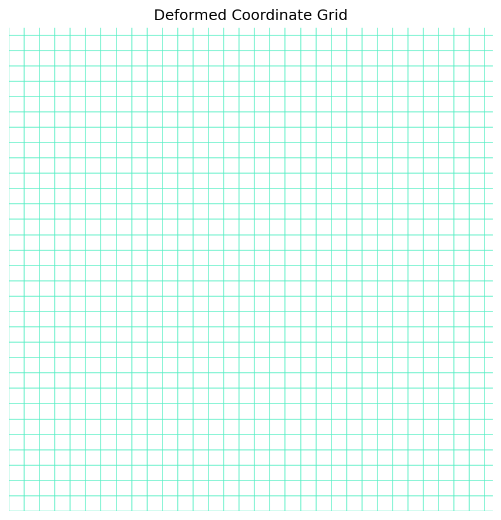

### Large Diff Both (Bias + Large Affine)

#### Target/Fixed vs Original Moving (Side-by-Side)

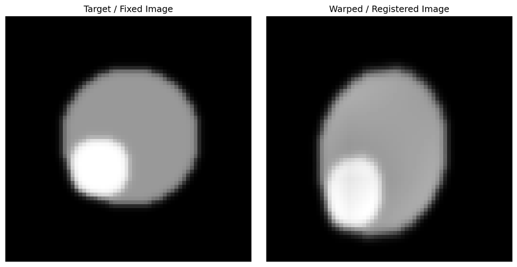

#### Edge Overlap

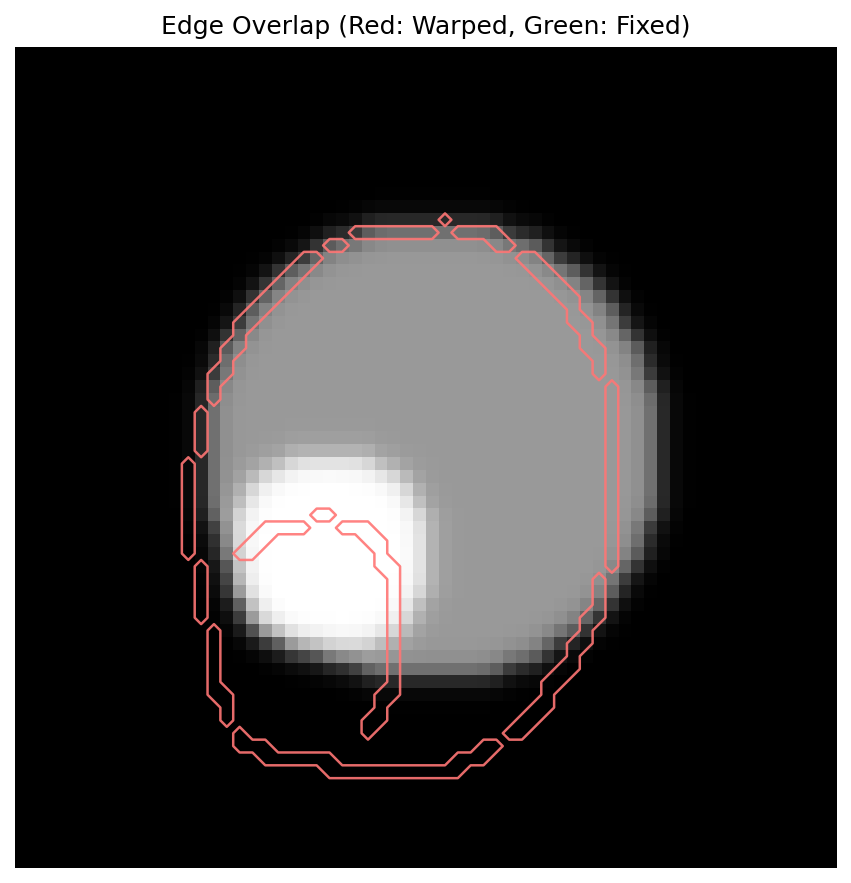

#### Deformation Grid

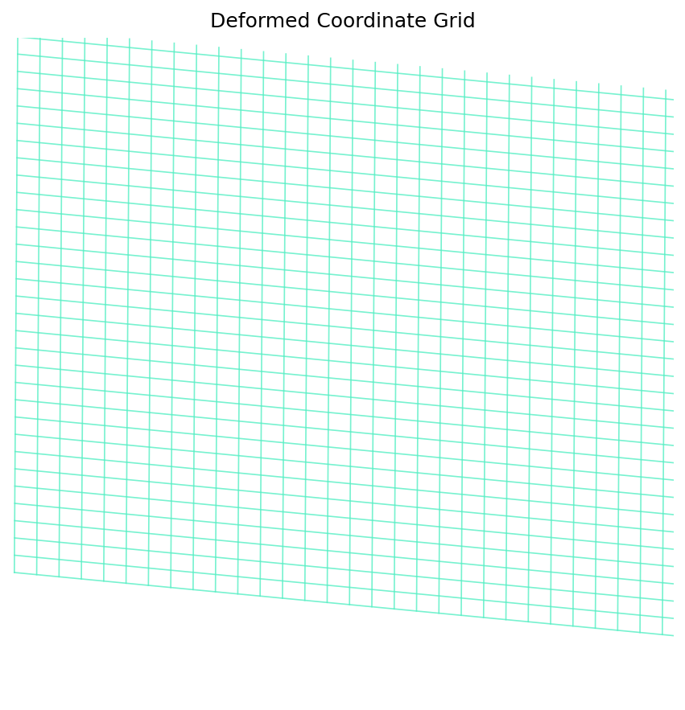

### Large Diff Both (Modality + Large Deformation)

#### Target/Fixed vs Original Moving (Side-by-Side)

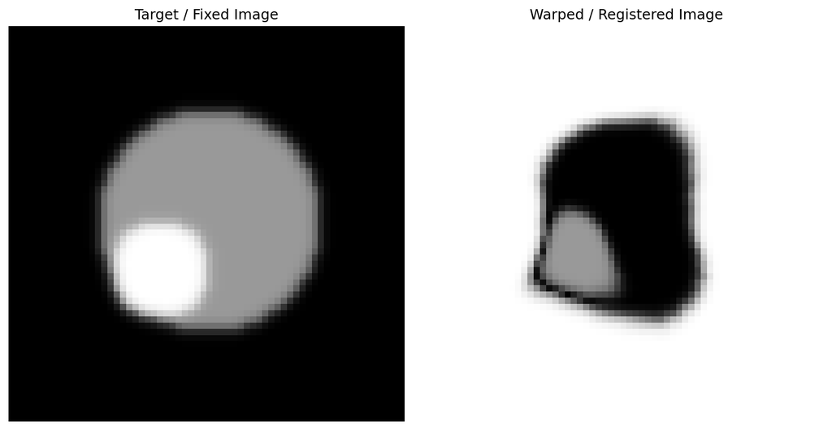

#### Edge Overlap

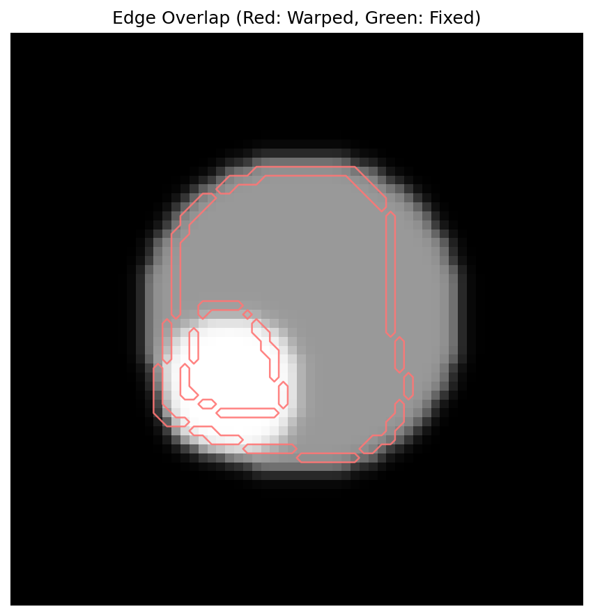

#### Deformation Grid

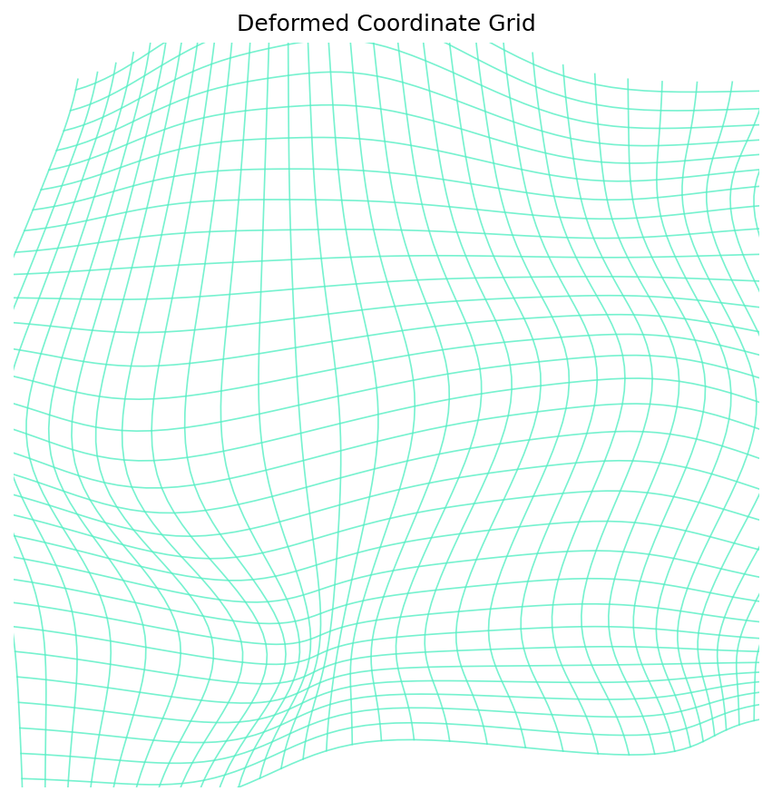